# Series de Tiempo Económicas

v. 2026.08.13

PDF

## ¿Qué son las series de tiempo?

## ¿Qué son las series de tiempo? (1/5)

Por **serie de tiempo** nos referimos a *datos estadísticos* que se recopilan, observan o registran en *intervalos de tiempo regulares*.

## ¿Qué son las series de tiempo? (2/5)

**Calentamiento global**

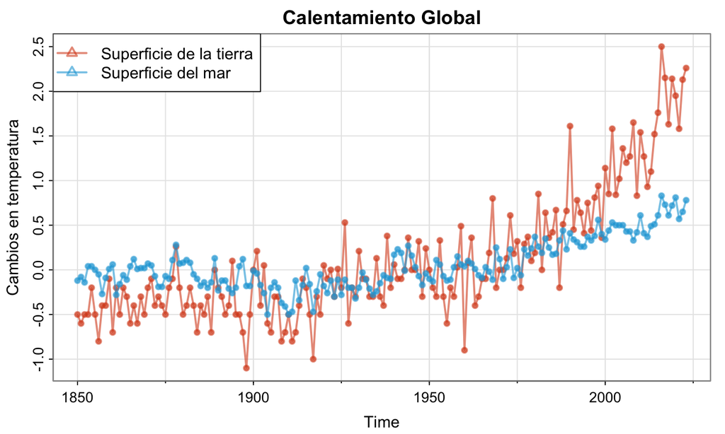

Desviaciones con respecto al promedio del periodo 1950-1980

## ¿Qué son las series de tiempo? (3/5)

**Johnson & Johnson**

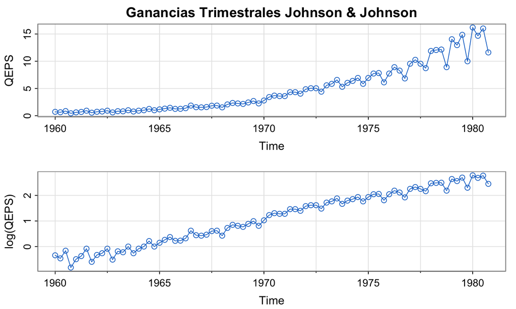

Ganancias trimestrales en niveles y en logaritmos.

## ¿Qué son las series de tiempo? (4/5)

**Dow Jones**

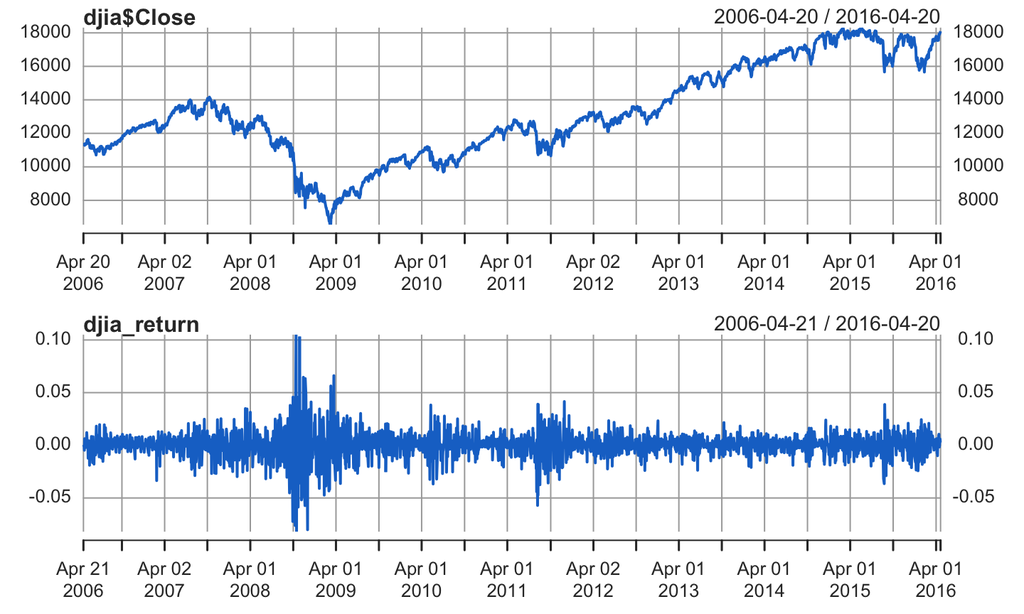

Índice y rendimientos.

## ¿Qué son las series de tiempo? (4/5)

**Crecimiento del PIB de Estados Unidos**

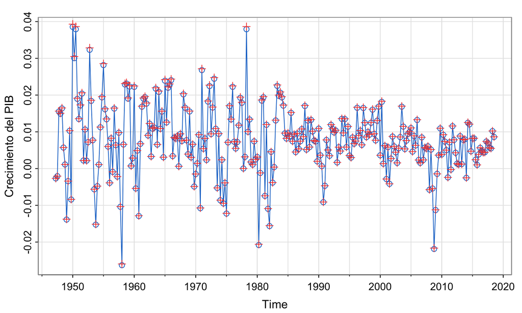

## Modelos de series de tiempo

## ¿En qué consiste un análisis de series temporales?

Un análisis de series temporales consiste en desarrollar modelos matemáticos que nos permitan describir los datos, tomando en cuenta las características específicas de estos:

1. **Tendencia**
2. **Componente estacional**
3. **Componente cíclico**
4. **Componente irregular**

## Ejemplos (1/4)

Un ejemplo de modelo de series temporales es el Ruido Blanco (Gaussiano).

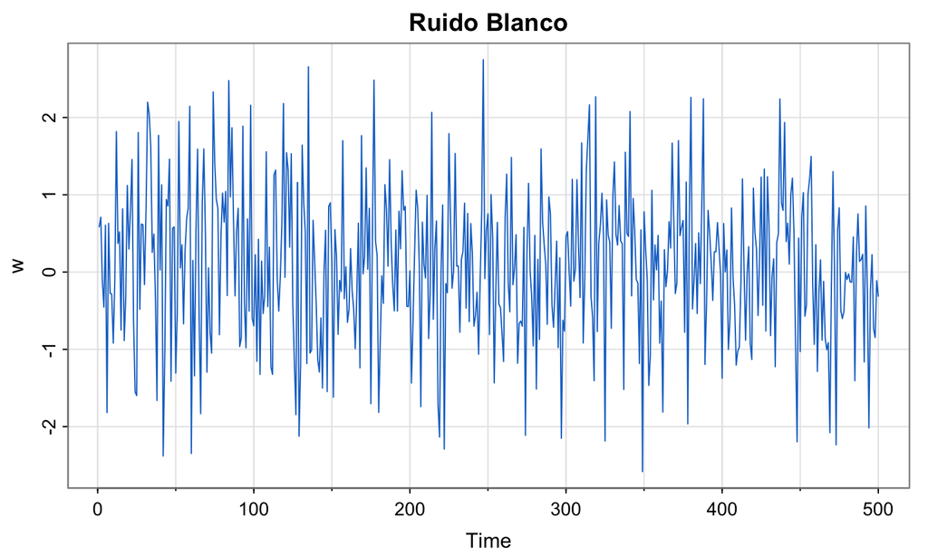

\[ \varepsilon_t \sim iid \mathcal{N}(0,1) \]

## Ejemplos (2/4)

Un modelo de medias móviles.

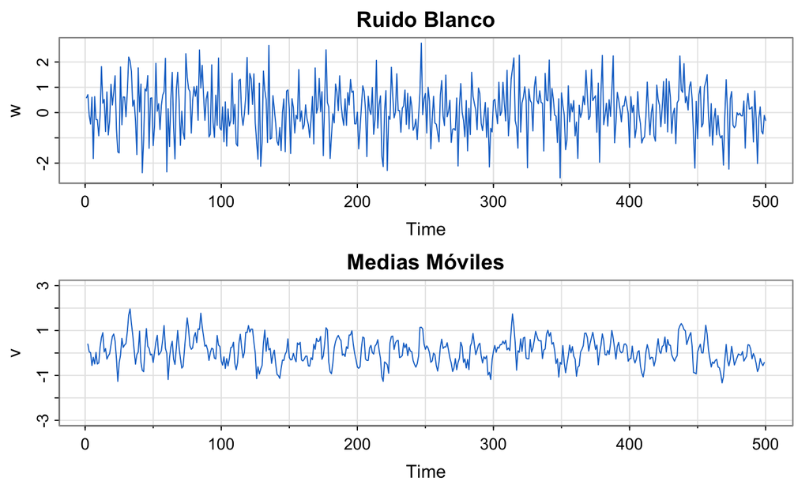

\[ \begin{align} &y_t = \frac{1}{3}(\varepsilon_{t-1}+\varepsilon_{t}+\varepsilon_{t+1}) \\ &\varepsilon_t \sim iid \mathcal{N}(0,1) \end{align} \]

## Ejemplos (3/4)

Modelos autorregresivos

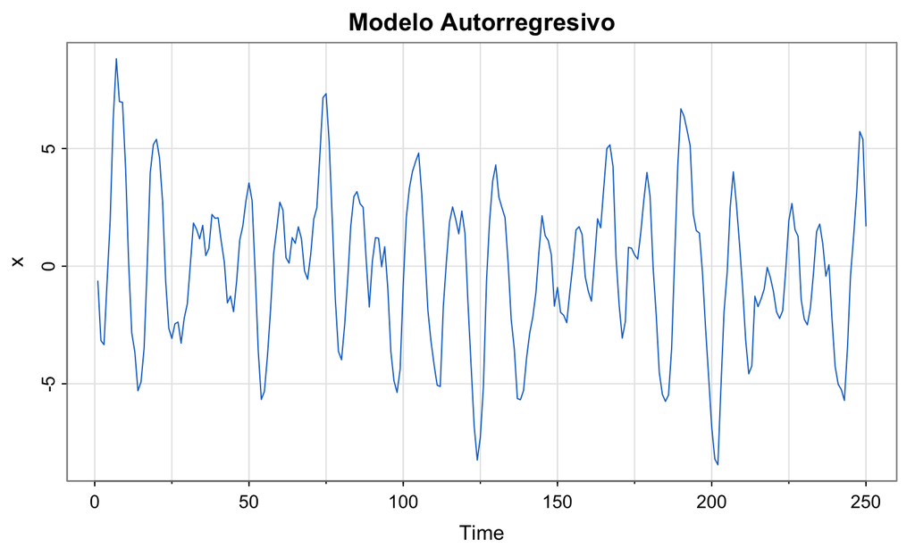

\[ \begin{align} &y_t = 1.5 y_{t-1}-0.75y_{t-2}+\varepsilon_{t} \\ &\varepsilon_t \sim iid \mathcal{N}(0,1) \end{align} \]

## Ejemplos (4/4)

Caminata aleatoria con deriva

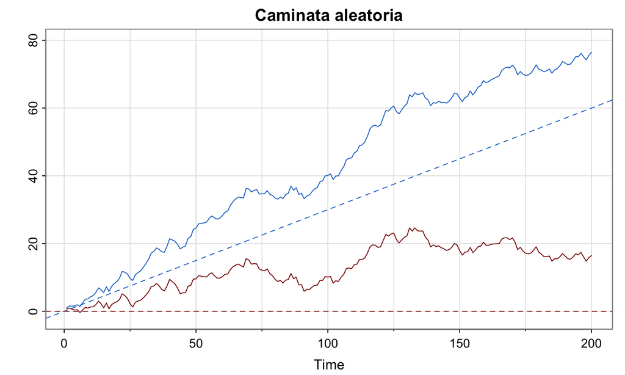

\[ \begin{align} &y_t = 0.3 + y_{t-1}+\varepsilon_{t} \\ &\varepsilon_t \sim iid \mathcal{N}(0,1) \end{align} \]

## Objetivos del curso y contenido

## Objetivos del curso

En este curso:

- Aprenderemos algunas de las técnicas para modelar una o varias series de tiempo, particularmente series de tiempo macroeconómicas.
- Utilizando los modelos aprendidos realizaremos pronósticos sobre el comportamiento de las series de tiempo.

## Contenido

**Parte I: Modelos univariados**

1. Introducción
2. Repaso: Ecuaciones en diferencias (autogestivo)
3. El concepto de estacionariedad
4. Modelos estacionarios
5. Modelos no estacionarios
6. Modelos con heteroscedasticidad condicional

**Parte II: Modelos multivariados**

7. Modelos VAR
8. Cointegración y modelos VECM

## Software

Utilizaremos principalmente **Gretl**, pero el estudiante puede optar por:

- R / RStudio
- Stata
- Eviews
- Python
- Julia

## Referencias

- **Brockwell**, P., y Davis, R. (2016). *Introduction to Time Series and Forecasting* (3rd Edition). Springer.
- **Enders**, W. (2014). *Applied Econometric Time Series* (4th Edition). Wiley.
- **Greene**, W. (2012). *Econometric Analysis* (7th Edition). Prentice Hall
- **Hamilton**, J., (1994). *Time Series Analysis*. Princeton University Press.

## Evaluación (1/2)

- Ejercicios: 10%
- Cuestionarios: 10%
- Lecturas: 10%
- Examenes parcial: 20%
- Examen Final: 50%
- Evaluación docente: 0% (¡Obligatoria!)

## Evaluación (2/2)

- *Todos* los exámenes se presentarán en forma presencial, a menos que exista un comunicado oficial de virtualidad por parte de la Universidad de Guanajuato.
- *La calificación final no se redondea hacia arriba*, a menos que el puntaje en el examen final sea superior a 5.0.
- *Bajo ninguna circunstancia* se asignará una calificación de NC a alumnos inscritos al finalizar el semestre.

## Seguimiento

*Moodle*: Campus Digital UG

- Material del curso (diapositivas, datos)
- Distribución de tareas y actividades

*Microsoft Teams*:

- Toda comunicación con el profesor (atencion de dudas, avisos, etc.)